# College Majors and Their ROI

Michaline Becknell

```r
# Load any R Packages you may need
library(tidyverse)
library(fivethirtyeight)
library(ggplot2)
```

#### Higher education is a massive investment. The reason that many people persue a bachelors degree is to get a better job in the future. What you majored in can often play a role in how much you make or how easily you can get a job after graduation. I am exploring fivethirtyeight’s dataset ‘college_recent_grads’ which contains 173 different college majors and tracks 21 variables for each. I will be analysing the data to find out how economic certain majors are. Because I am focusin on ROI, the most pertinent variables to me are ones like ‘median’ (salary) and ‘unemployment_rate’.

### The first question I wanted to ask was: what are the relative levels of certain major’s median salaries and unemployment post-grad? (the list of majors are ones I was personally interested in at one point or another)

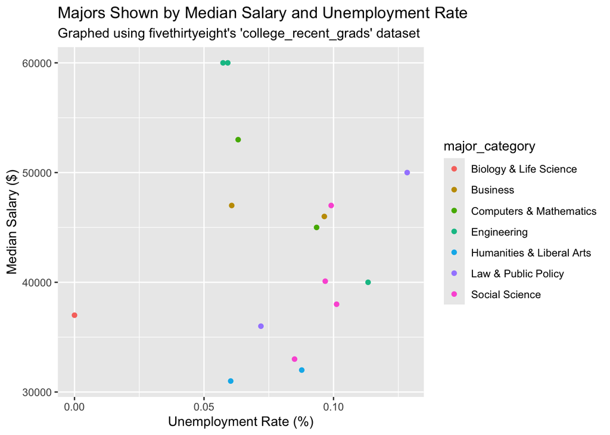

### The next question is more broad: by major_catagory, which degrees have better employment rates compared to the average?

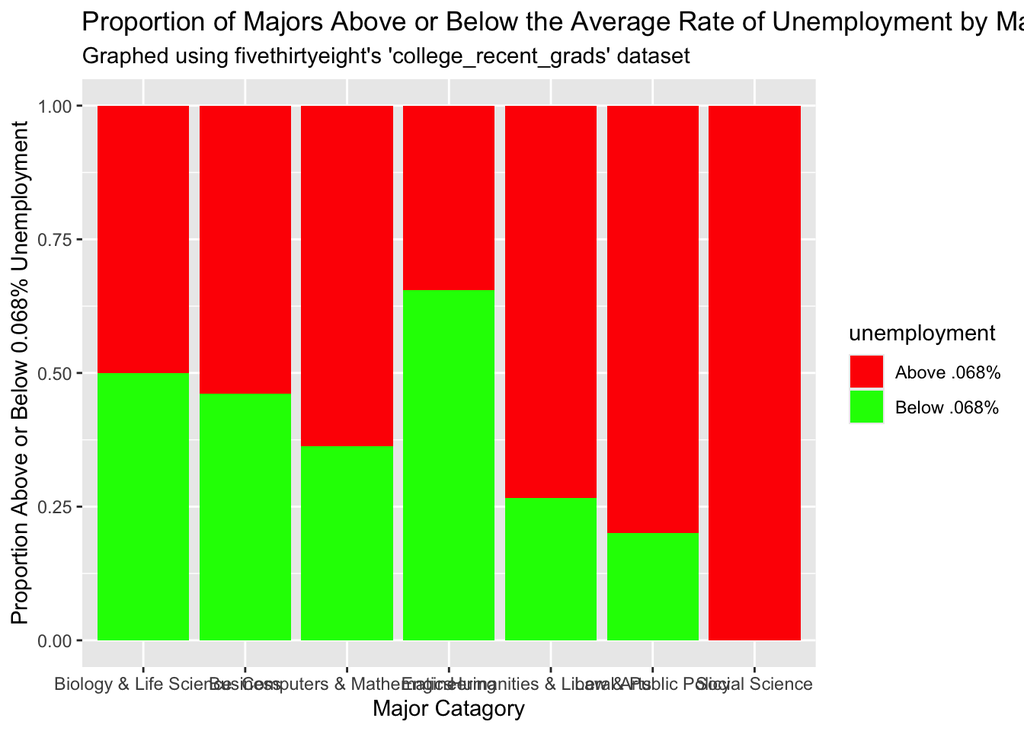

###*After calculating the average unemployment rate of .068%, I filtered the individual majors into “Above” and “Below” using the average as a cut-off value. Then the majors are displayed here by major category with their proportion of degrees above or below the average unemployment level. Looking at the graph, it seems that the Engineering category has the lowest proportion of degrees with above average unemployment and the Social Science category has the highest (100%!). It also seems that the STEM categories have a lower proportion of degrees with above average unemployment post-graduation compared to the humanities categories.*